# Tarea 10 Estudio de recién nacidos

Pedro Biel

23/2/2021

Instala y carga el paquete `MASS`.

En el hay una tabla de datos llamada `birthwt` sobre factores que pueden incidir en el peso de los niños al nacer.

```r
library(MASS)
```

# Preguntas de esta tarea

## 1. Utiliza `str()` y `head()` para explorar la estructura, y con `help()`, mirar el significado de cada variable.

```r
str(birthwt)
```

```
## 'data.frame':    189 obs. of  10 variables:
##  $ low  : int  0 0 0 0 0 0 0 0 0 0 ...
##  $ age  : int  19 33 20 21 18 21 22 17 29 26 ...
##  $ lwt  : int  182 155 105 108 107 124 118 103 123 113 ...
##  $ race : int  2 3 1 1 1 3 1 3 1 1 ...
##  $ smoke: int  0 0 1 1 1 0 0 0 1 1 ...
##  $ ptl  : int  0 0 0 0 0 0 0 0 0 0 ...
##  $ ht   : int  0 0 0 0 0 0 0 0 0 0 ...
##  $ ui   : int  1 0 0 1 1 0 0 0 0 0 ...
##  $ ftv  : int  0 3 1 2 0 0 1 1 1 0 ...
##  $ bwt  : int  2523 2551 2557 2594 2600 2622 2637 2637 2663 2665 ...
```

```r
head(birthwt)
```

```
##    low age lwt race smoke ptl ht ui ftv  bwt
## 85   0  19 182    2     0   0  0  1   0 2523
## 86   0  33 155    3     0   0  0  0   3 2551
## 87   0  20 105    1     1   0  0  0   1 2557
## 88   0  21 108    1     1   0  0  1   2 2594
## 89   0  18 107    1     1   0  0  1   0 2600
## 91   0  21 124    3     0   0  0  0   0 2622
```

```r
help(birthwt)
```

```
## starting httpd help server ... done
```

## 2. Calcula una tabla de frecuencias relativas marginales de los pares (raza de la madre, peso inferior a 2.5 kg o no) que permita ver si la raza de la madre influye en el peso del bebé.

```r
prop.table(table(birthwt$low, birthwt$race), margin = 1)
```

```
##
##             1         2         3
##   0 0.5615385 0.1153846 0.3230769
##   1 0.3898305 0.1864407 0.4237288
```

```r
raza <- factor(birthwt$race, labels = c('blanca', 'negra', 'otra'))
peso <- factor(birthwt$low, labels = c('>=  2.5 kg', ' < 2.5 kg'))
round(prop.table(table(peso, raza), margin = 1), 3)
```

```
##             raza
## peso         blanca negra  otra
##   >=  2.5 kg  0.562 0.115 0.323
##    < 2.5 kg   0.390 0.186 0.424
```

## 3. Dibuja un diagrama de mosaico de la tabla del ejercicio anterior.

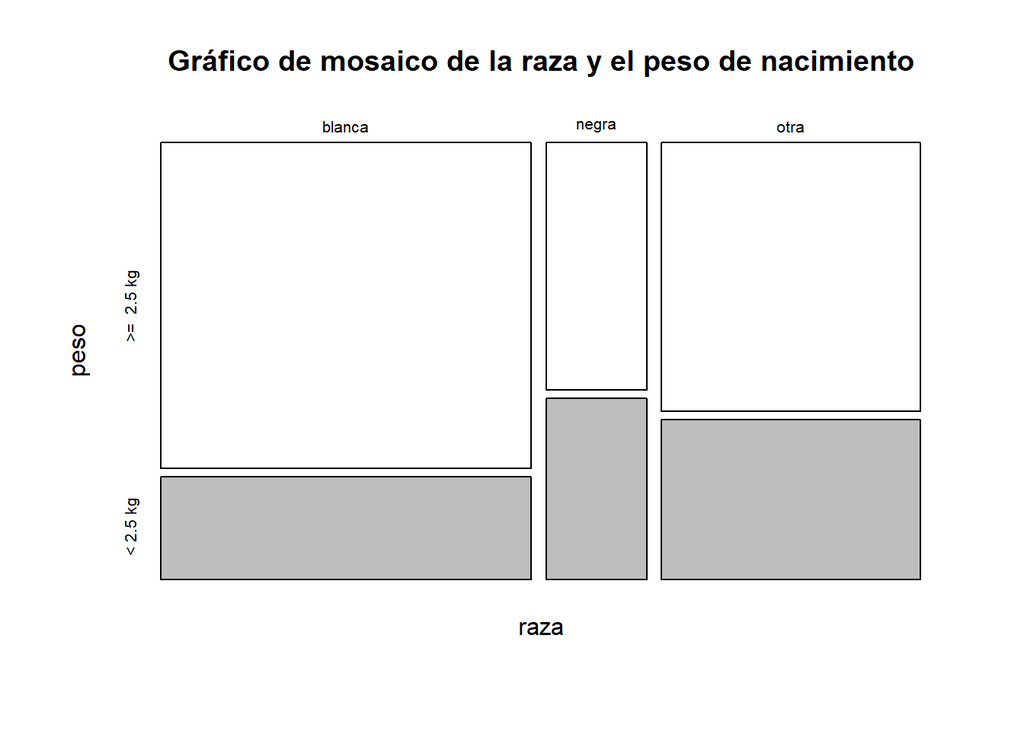

```r
plot(table(raza, peso),
     main = 'Gráfico de mosaico de la raza y el peso de nacimiento',
     col = c('white', 'gray')
     )
```

## 4. Dibuja un diagrama bidimensional de barras, con las barras organizadas en bloques, que permita visualizar la información de los ejercicios anteriores. Aprovecha para nombres adecuados a los bloques, colores a las barras, y añadir una leyenda que explique qué representa cada barra.

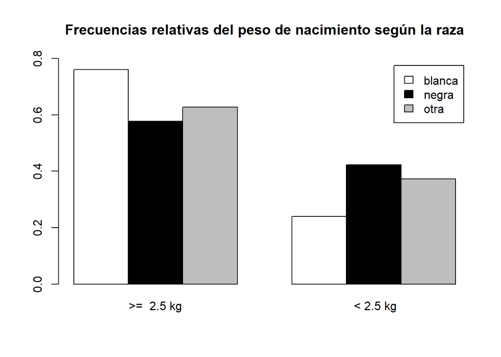

```r
barplot(prop.table(table(raza, peso), margin = 1), beside = TRUE,
        legend.text = TRUE, ylim = c(0, 0.8),
        col = c('white', 'black', 'gray'),
        main = 'Frecuencias relativas del peso de nacimiento según la raza'
        )
```

## 5. ¿Se puede obtener alguna conclusión de la tabla y el diagrama de barras anterior? Argumenta tu respuesta

Según la tabla la raza blanca acumula más de un 56 % de los nacimientos con un peso igual o mayor a 2.5 kg, mientras que la raza negra está en último lugar con un 11.5 %.

Con los nacimientos con un peso inferior a 2.5 kg la raza blanca y otras están más igualadas en porcentaje, mientras que la raza negra sigue en último lugar.

El el gráfico se ve que el mayor porcentaje de nacimientos con un peso igual o mayor que 2.5 kg es la raza blanca, seguida de otra y la raza negra.

## 6. Repite los cuatro ejercicios anteriores para los pares (madre fumadora o no, peso inferior a 2.5 kg o no) y para los pares (madre hipertensa o no, peso inferior a 2.5 kg o no.

```r
prop.table(table(birthwt$low, birthwt$smoke), margin = 1)
```

```
##
##             0         1
##   0 0.6615385 0.3384615
##   1 0.4915254 0.5084746
```

```r
fuma <- factor(birthwt$smoke, labels = c('no', 'sí'))
peso <- factor(birthwt$low, labels = c('>=  2.5 kg', ' < 2.5 kg'))
round(prop.table(table(peso, fuma), margin = 1), 3)
```

```
##             fuma
## peso            no    sí
##   >=  2.5 kg 0.662 0.338
##    < 2.5 kg  0.492 0.508
```

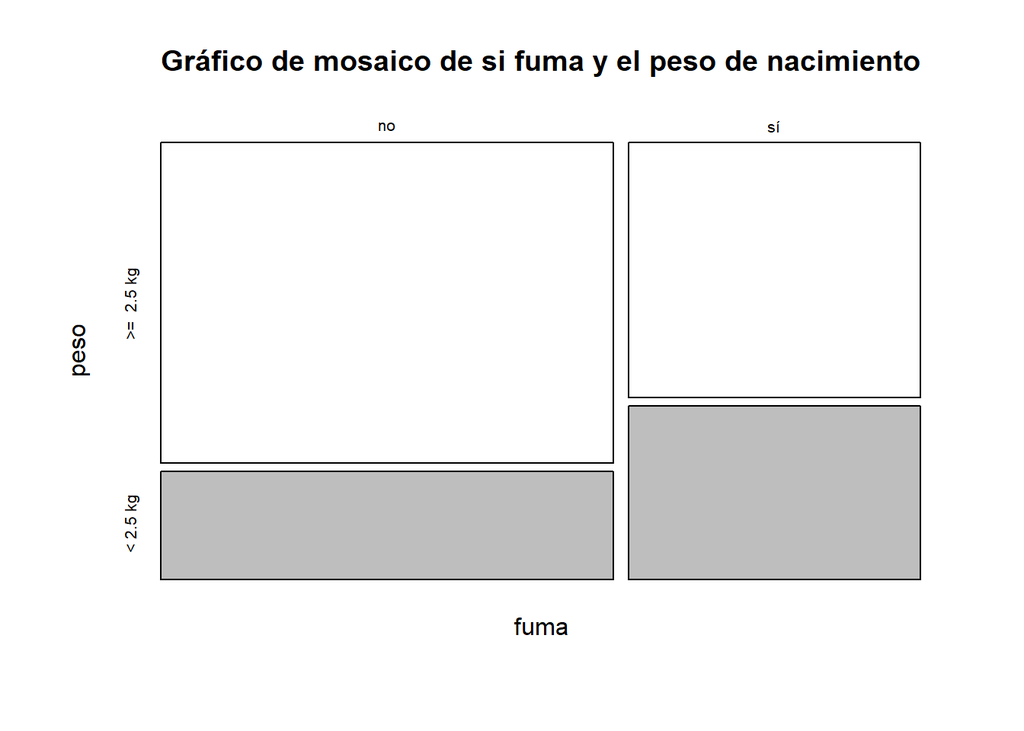

```r
plot(table(fuma, peso),
     main = 'Gráfico de mosaico de si fuma y el peso de nacimiento',
     col = c('white', 'gray')
     )
```

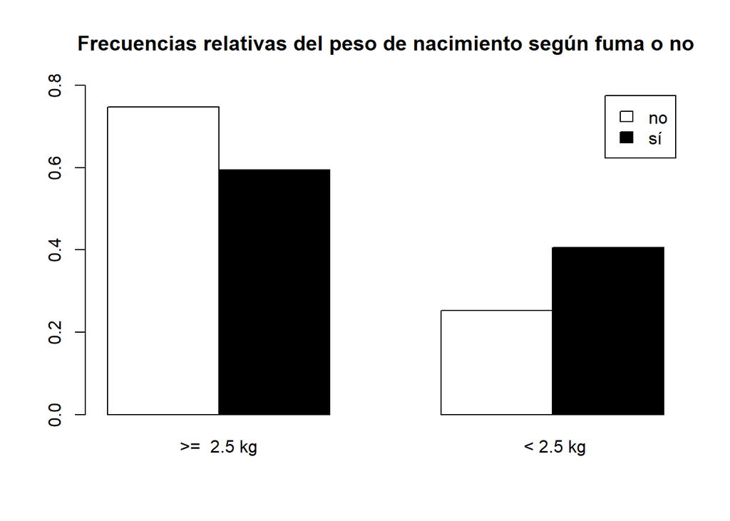

```r
barplot(prop.table(table(fuma, peso), margin = 1), beside = TRUE,
        legend.text = TRUE, ylim = c(0, 0.8),
        col = c('white', 'black'),
        main = 'Frecuencias relativas del peso de nacimiento según fuma o no'
        )
```

Supongo que `smoke = 0` es no fumadora y `smoke = 1` es fumadora.

Según los resultados los neonatos de madres no fumadoras tienden a tener mayor peso.

```r
prop.table(table(birthwt$low, birthwt$ht), margin = 1)
```

```
##
##              0          1
##   0 0.96153846 0.03846154
##   1 0.88135593 0.11864407
```

```r
hipertensa <- factor(birthwt$ht, labels = c('no', 'sí'))
peso <- factor(birthwt$low, labels = c('>=  2.5 kg', ' < 2.5 kg'))
round(prop.table(table(peso, hipertensa), margin = 1), 3)
```

```
##             hipertensa
## peso            no    sí
##   >=  2.5 kg 0.962 0.038
##    < 2.5 kg  0.881 0.119
```

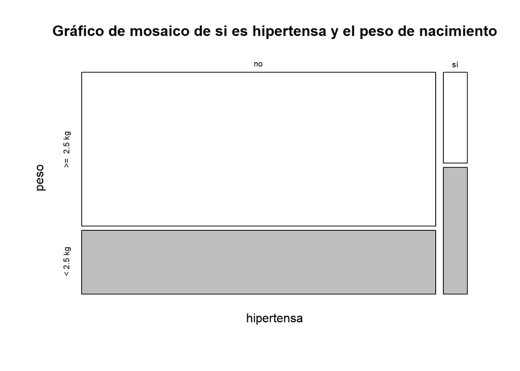

```r
plot(table(hipertensa, peso),
     main = 'Gráfico de mosaico de si es hipertensa y el peso de nacimiento',
     col = c('white', 'gray')
     )
```

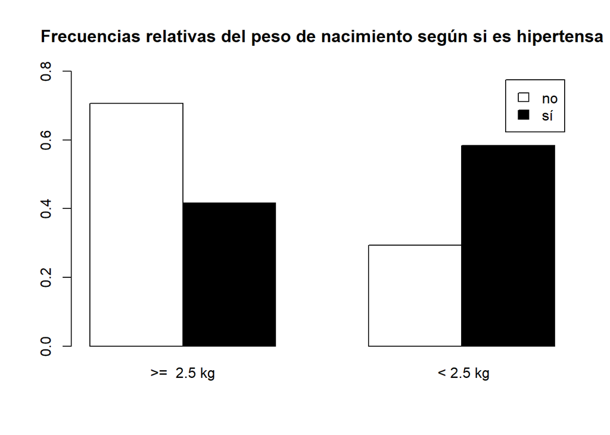

```r
barplot(prop.table(table(hipertensa, peso), margin = 1), beside = TRUE,
        legend.text = TRUE, ylim = c(0, 0.8),
        col = c('white', 'black'),
        main = 'Frecuencias relativas del peso de nacimiento según si es hipertensa'
        )
```

Supongo que `ht = 0` es no hipertensa y `ht = 1` es hipertensa.

Según los resultados los neonatos de madres hipertensas tienden a tener menor peso.

## 7. Calcula una tabla de frecuencias relativas marginales de las ternas (raza de la madre, madre fumadora o no, peso inferior a 2.5 kg o no) que permita ver si la raza de la madre y su condición de fumadora o no fumadora influyen en el peso del bebé.

```r
prop.table(table(birthwt$low, birthwt$smoke, birthwt$race), margin = 1)
```

```
## , ,  = 1
##
##
##              0          1
##   0 0.30769231 0.25384615
##   1 0.06779661 0.32203390
##
## , ,  = 2
##
##
##              0          1
##   0 0.08461538 0.03076923
##   1 0.08474576 0.10169492
##
## , ,  = 3
##
##
##              0          1
##   0 0.26923077 0.05384615
##   1 0.33898305 0.08474576
```

```r
raza <- factor(birthwt$race, labels = c('blanca', 'negra', 'otra'))
fuma <- factor(birthwt$smoke, labels = c('no', 'sí'))
peso <- factor(birthwt$low, labels = c('>=  2.5 kg', ' < 2.5 kg'))
round(prop.table(table(peso, fuma, raza), margin = 2), 3)
```

```
## , , raza = blanca
##
##             fuma
## peso            no    sí
##   >=  2.5 kg 0.348 0.446
##    < 2.5 kg  0.035 0.257
##
## , , raza = negra
##
##             fuma
## peso            no    sí
##   >=  2.5 kg 0.096 0.054
##    < 2.5 kg  0.043 0.081
##
## , , raza = otra
##
##             fuma
## peso            no    sí
##   >=  2.5 kg 0.304 0.095
##    < 2.5 kg  0.174 0.068
```

En todas las razas, si la madre no fuma, el peso del neonato tiende a ser mayor.

## 8. Dibuja un diagrama de mosaico de la tabla del ejercicio anterior.

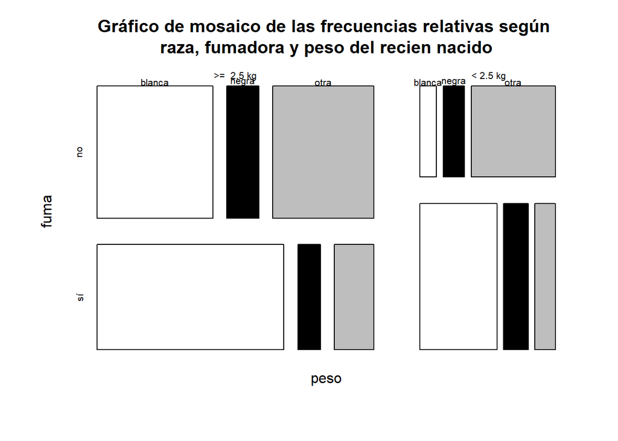

```r
plot(prop.table(table(peso, fuma, raza), margin = 2),
     col = c('white', 'black', 'gray'),
     main = 'Gráfico de mosaico de las frecuencias relativas según \nraza, fumadora y peso del recien nacido'
)
```